# **Problem Statement**

## Business Context

Renewable energy sources play an increasingly important role in the global energy mix, as the effort to reduce the environmental impact of energy production increases.

Out of all the renewable energy alternatives, wind energy is one of the most developed technologies worldwide. The U.S Department of Energy has put together a guide to achieving operational efficiency using predictive maintenance practices.

Predictive maintenance uses sensor information and analysis methods to measure and predict degradation and future component capability. The idea behind predictive maintenance is that failure patterns are predictable and if component failure can be predicted accurately and the component is replaced before it fails, the costs of operation and maintenance will be much lower.

The sensors fitted across different machines involved in the process of energy generation collect data related to various environmental factors (temperature, humidity, wind speed, etc.) and additional features related to various parts of the wind turbine (gearbox, tower, blades, break, etc.).

## Objective

“ReneWind” is a company working on improving the machinery/processes involved in the production of wind energy using machine learning and has collected data of generator failure of wind turbines using sensors. They have shared a ciphered version of the data, as the data collected through sensors is confidential (the type of data collected varies with companies). Data has 40 predictors, 20000 observations in the training set and 5000 in the test set.

The objective is to build various classification models, tune them, and find the best one that will help identify failures so that the generators could be repaired before failing/breaking to reduce the overall maintenance cost. The nature of predictions made by the classification model will translate as follows:

- True positives (TP) are failures correctly predicted by the model. These will result in repairing costs.
- False negatives (FN) are real failures where there is no detection by the model. These will result in replacement costs.
- False positives (FP) are detections where there is no failure. These will result in inspection costs.

It is given that the cost of repairing a generator is much less than the cost of replacing it, and the cost of inspection is less than the cost of repair.

“1” in the target variables should be considered as “failure” and “0” represents “No failure”.

## Data Description

The data provided is a transformed version of the original data which was collected using sensors.

- Train.csv - To be used for training and tuning of models.
- Test.csv - To be used only for testing the performance of the final best model.

Both the datasets consist of 40 predictor variables and 1 target variable.

# 1 - Installing and Importing the necessary libraries

```python
# Standard library
import os
import time
import warnings

# Data and visualization
import numpy as np
import pandas as pd
import matplotlib.pyplot as plt
import seaborn as sns

from IPython.display import display

# Scikit-learn
from sklearn.impute import SimpleImputer
from sklearn.metrics import (
    accuracy_score,
    confusion_matrix,
    f1_score,
    precision_score,
    recall_score,
)
from sklearn.model_selection import train_test_split
from sklearn.preprocessing import StandardScaler

# TensorFlow / Keras
import tensorflow as tf
from tensorflow.keras import Sequential
from tensorflow.keras.layers import Dense, Dropout, Input
from tensorflow.keras.optimizers import SGD, Adam

# Reproducibility and clean submission output
warnings.filterwarnings("ignore")
os.environ["TF_CPP_MIN_LOG_LEVEL"] = "2"
SEED = 1
np.random.seed(SEED)
tf.random.set_seed(SEED)

pd.set_option("display.max_columns", None)
pd.set_option("display.max_rows", 100)
sns.set_style("whitegrid")
```

[output not shown]

[output not shown]

# 2 - Import Dataset

```python
DATA_DIR = "data"
train_path = os.path.join(DATA_DIR, "Train.csv")
test_path = os.path.join(DATA_DIR, "Test.csv")

data = pd.read_csv(train_path)
test_data = pd.read_csv(test_path)

data_copy = data.copy()
test_copy = test_data.copy()
```

# 3 - Data Overview

```python
data.head()
```

|  | V1 | V2 | V3 | V4 | V5 | V6 | V7 | V8 | V9 | V10 | V11 | V12 | V13 | V14 | V15 | V16 | V17 | V18 | V19 | V20 | V21 | V22 | V23 | V24 | V25 | V26 | V27 | V28 | V29 | … |
| --- | --- | --- | --- | --- | --- | --- | --- | --- | --- | --- | --- | --- | --- | --- | --- | --- | --- | --- | --- | --- | --- | --- | --- | --- | --- | --- | --- | --- | --- | --- |
| 0 | -4.464606 | -4.679129 | 3.101546 | 0.506130 | -0.221083 | -2.032511 | -2.910870 | 0.050714 | -1.522351 | 3.761892 | -5.714719 | 0.735893 | 0.981251 | 1.417884 | -3.375815 | -3.047303 | 0.306194 | 2.914097 | 2.269979 | 4.394876 | -2.388299 | 0.646388 | -1.190508 | 3.132986 | 0.665277 | -2.510846 | -0.036744 | 0.726218 | -3.982187 | … |
| 1 | 3.365912 | 3.653381 | 0.909671 | -1.367528 | 0.332016 | 2.358938 | 0.732600 | -4.332135 | 0.565695 | -0.101080 | 1.914465 | -0.951458 | -1.255259 | -2.706522 | 0.193223 | -4.769379 | -2.205319 | 0.907716 | 0.756894 | -5.833678 | -3.065122 | 1.596647 | -1.757311 | 1.766444 | -0.267098 | 3.625036 | 1.500346 | -0.585712 | 0.783034 | … |
| 2 | -3.831843 | -5.824444 | 0.634031 | -2.418815 | -1.773827 | 1.016824 | -2.098941 | -3.173204 | -2.081860 | 5.392621 | -0.770673 | 1.106718 | 1.144261 | 0.943301 | -3.163804 | -4.247825 | -4.038909 | 3.688534 | 3.311196 | 1.059002 | -2.143026 | 1.650120 | -1.660592 | 1.679910 | -0.450782 | -4.550695 | 3.738779 | 1.134404 | -2.033531 | … |
| 3 | 1.618098 | 1.888342 | 7.046143 | -1.147285 | 0.083080 | -1.529780 | 0.207309 | -2.493629 | 0.344926 | 2.118578 | -3.053023 | 0.459719 | 2.704527 | -0.636086 | -0.453717 | -3.174046 | -3.404347 | -1.281536 | 1.582104 | -1.951778 | -3.516555 | -1.206011 | -5.627854 | -1.817653 | 2.124142 | 5.294642 | 4.748137 | -2.308536 | -3.962977 | … |
| 4 | -0.111440 | 3.872488 | -3.758361 | -2.982897 | 3.792714 | 0.544960 | 0.205433 | 4.848994 | -1.854920 | -6.220023 | 1.998347 | 4.723757 | 0.709113 | -1.989432 | -2.632684 | 4.184447 | 2.245356 | 3.734452 | -6.312766 | -5.379918 | -0.886667 | 2.061694 | 9.445586 | 4.489976 | -3.945144 | 4.582065 | -8.780422 | -3.382967 | 5.106507 | … |

```python
test_data.head()
```

|  | V1 | V2 | V3 | V4 | V5 | V6 | V7 | V8 | V9 | V10 | V11 | V12 | V13 | V14 | V15 | V16 | V17 | V18 | V19 | V20 | V21 | V22 | V23 | V24 | V25 | V26 | V27 | V28 | V29 | … |
| --- | --- | --- | --- | --- | --- | --- | --- | --- | --- | --- | --- | --- | --- | --- | --- | --- | --- | --- | --- | --- | --- | --- | --- | --- | --- | --- | --- | --- | --- | --- |
| 0 | -0.613489 | -3.819640 | 2.202302 | 1.300420 | -1.184929 | -4.495964 | -1.835817 | 4.722989 | 1.206140 | -0.341909 | -5.122874 | 1.017021 | 4.818549 | 3.269001 | -2.984330 | 1.387370 | 2.032002 | -0.511587 | -1.023069 | 7.338733 | -2.242244 | 0.155489 | 2.053786 | -2.772273 | 1.851369 | -1.788696 | -0.277282 | -1.255143 | -3.832886 | … |
| 1 | 0.389608 | -0.512341 | 0.527053 | -2.576776 | -1.016766 | 2.235112 | -0.441301 | -4.405744 | -0.332869 | 1.966794 | 1.796544 | 0.410490 | 0.638328 | -1.389600 | -1.883410 | -5.017922 | -3.827238 | 2.418060 | 1.762285 | -3.242297 | -3.192960 | 1.857454 | -1.707954 | 0.633444 | -0.587898 | 0.083683 | 3.013935 | -0.182309 | 0.223917 | … |
| 2 | -0.874861 | -0.640632 | 4.084202 | -1.590454 | 0.525855 | -1.957592 | -0.695367 | 1.347309 | -1.732348 | 0.466500 | -4.928214 | 3.565070 | -0.449329 | -0.656246 | -0.166537 | -1.630207 | 2.291865 | 2.396492 | 0.601278 | 1.793534 | -2.120238 | 0.481968 | -0.840707 | 1.790197 | 1.874395 | 0.363930 | -0.169063 | -0.483832 | -2.118982 | … |
| 3 | 0.238384 | 1.458607 | 4.014528 | 2.534478 | 1.196987 | -3.117330 | -0.924035 | 0.269493 | 1.322436 | 0.702345 | -5.578345 | -0.850662 | 2.590525 | 0.767418 | -2.390809 | -2.341961 | 0.571875 | -0.933751 | 0.508677 | 1.210715 | -3.259524 | 0.104587 | -0.658875 | 1.498107 | 1.100305 | 4.142988 | -0.248446 | -1.136516 | -5.355810 | … |
| 4 | 5.828225 | 2.768260 | -1.234530 | 2.809264 | -1.641648 | -1.406698 | 0.568643 | 0.965043 | 1.918379 | -2.774855 | -0.530016 | 1.374544 | -0.650941 | -1.679466 | -0.379220 | -4.443143 | 3.893857 | -0.607640 | 2.944931 | 0.367233 | -5.789081 | 4.597528 | 4.450264 | 3.224941 | 0.396701 | 0.247765 | -2.362047 | 1.079378 | -0.473076 | … |

```python
print('Train shape:', data.shape)
print('Test shape:', test_data.shape)
```

```
Train shape: (20000, 41)
Test shape: (5000, 41)
```

```python
data.info()
```

```
<class 'pandas.DataFrame'>
RangeIndex: 20000 entries, 0 to 19999
Data columns (total 41 columns):
 #   Column  Non-Null Count  Dtype
---  ------  --------------  -----
 0   V1      19982 non-null  float64
 1   V2      19982 non-null  float64
 2   V3      20000 non-null  float64
 3   V4      20000 non-null  float64
 4   V5      20000 non-null  float64
 5   V6      20000 non-null  float64
 6   V7      20000 non-null  float64
 7   V8      20000 non-null  float64
 8   V9      20000 non-null  float64
 9   V10     20000 non-null  float64
```

[output cut: 33 more lines]

```python
data.describe(include='all').T
```

|  | count | mean | std | min | 25% | 50% | 75% | max |
| --- | --- | --- | --- | --- | --- | --- | --- | --- |
| V1 | 19982.0 | -0.271996 | 3.441625 | -11.876451 | -2.737146 | -0.747917 | 1.840112 | 15.493002 |
| V2 | 19982.0 | 0.440430 | 3.150784 | -12.319951 | -1.640674 | 0.471536 | 2.543967 | 13.089269 |
| V3 | 20000.0 | 2.484699 | 3.388963 | -10.708139 | 0.206860 | 2.255786 | 4.566165 | 17.090919 |
| V4 | 20000.0 | -0.083152 | 3.431595 | -15.082052 | -2.347660 | -0.135241 | 2.130615 | 13.236381 |
| V5 | 20000.0 | -0.053752 | 2.104801 | -8.603361 | -1.535607 | -0.101952 | 1.340480 | 8.133797 |
| V6 | 20000.0 | -0.995443 | 2.040970 | -10.227147 | -2.347238 | -1.000515 | 0.380330 | 6.975847 |
| V7 | 20000.0 | -0.879325 | 1.761626 | -7.949681 | -2.030926 | -0.917179 | 0.223695 | 8.006091 |
| V8 | 20000.0 | -0.548195 | 3.295756 | -15.657561 | -2.642665 | -0.389085 | 1.722965 | 11.679495 |
| V9 | 20000.0 | -0.016808 | 2.160568 | -8.596313 | -1.494973 | -0.067597 | 1.409203 | 8.137580 |
| V10 | 20000.0 | -0.012998 | 2.193201 | -9.853957 | -1.411212 | 0.100973 | 1.477045 | 8.108472 |
| V11 | 20000.0 | -1.895393 | 3.124322 | -14.832058 | -3.922404 | -1.921237 | 0.118906 | 11.826433 |
| V12 | 20000.0 | 1.604825 | 2.930454 | -12.948007 | -0.396514 | 1.507841 | 3.571454 | 15.080698 |
| V13 | 20000.0 | 1.580486 | 2.874658 | -13.228247 | -0.223545 | 1.637185 | 3.459886 | 15.419616 |
| V14 | 20000.0 | -0.950632 | 1.789651 | -7.738593 | -2.170741 | -0.957163 | 0.270677 | 5.670664 |
| V15 | 20000.0 | -2.414993 | 3.354974 | -16.416606 | -4.415322 | -2.382617 | -0.359052 | 12.246455 |
| V16 | 20000.0 | -2.925225 | 4.221717 | -20.374158 | -5.634240 | -2.682705 | -0.095046 | 13.583212 |
| V17 | 20000.0 | -0.134261 | 3.345462 | -14.091184 | -2.215611 | -0.014580 | 2.068751 | 16.756432 |
| V18 | 20000.0 | 1.189347 | 2.592276 | -11.643994 | -0.403917 | 0.883398 | 2.571770 | 13.179863 |
| V19 | 20000.0 | 1.181808 | 3.396925 | -13.491784 | -1.050168 | 1.279061 | 3.493299 | 13.237742 |
| V20 | 20000.0 | 0.023608 | 3.669477 | -13.922659 | -2.432953 | 0.033415 | 2.512372 | 16.052339 |
| V21 | 20000.0 | -3.611252 | 3.567690 | -17.956231 | -5.930360 | -3.532888 | -1.265884 | 13.840473 |
| V22 | 20000.0 | 0.951835 | 1.651547 | -10.122095 | -0.118127 | 0.974687 | 2.025594 | 7.409856 |
| V23 | 20000.0 | -0.366116 | 4.031860 | -14.866128 | -3.098756 | -0.262093 | 2.451750 | 14.458734 |
| V24 | 20000.0 | 1.134389 | 3.912069 | -16.387147 | -1.468062 | 0.969048 | 3.545975 | 17.163291 |
| V25 | 20000.0 | -0.002186 | 2.016740 | -8.228266 | -1.365178 | 0.025050 | 1.397112 | 8.223389 |
| V26 | 20000.0 | 1.873785 | 3.435137 | -11.834271 | -0.337863 | 1.950531 | 4.130037 | 16.836410 |
| V27 | 20000.0 | -0.612413 | 4.368847 | -14.904939 | -3.652323 | -0.884894 | 2.189177 | 17.560404 |
| V28 | 20000.0 | -0.883218 | 1.917713 | -9.269489 | -2.171218 | -0.891073 | 0.375884 | 6.527643 |
| V29 | 20000.0 | -0.985625 | 2.684365 | -12.579469 | -2.787443 | -1.176181 | 0.629773 | 10.722055 |
| V30 | 20000.0 | -0.015534 | 3.005258 | -14.796047 | -1.867114 | 0.184346 | 2.036229 | 12.505812 |
| V31 | 20000.0 | 0.486842 | 3.461384 | -13.722760 | -1.817772 | 0.490304 | 2.730688 | 17.255090 |
| V32 | 20000.0 | 0.303799 | 5.500400 | -19.876502 | -3.420469 | 0.052073 | 3.761722 | 23.633187 |
| V33 | 20000.0 | 0.049825 | 3.575285 | -16.898353 | -2.242857 | -0.066249 | 2.255134 | 16.692486 |
| V34 | 20000.0 | -0.462702 | 3.183841 | -17.985094 | -2.136984 | -0.255008 | 1.436935 | 14.358213 |
| V35 | 20000.0 | 2.229620 | 2.937102 | -15.349803 | 0.336191 | 2.098633 | 4.064358 | 15.291065 |
| V36 | 20000.0 | 1.514809 | 3.800860 | -14.833178 | -0.943809 | 1.566526 | 3.983939 | 19.329576 |
| V37 | 20000.0 | 0.011316 | 1.788165 | -5.478350 | -1.255819 | -0.128435 | 1.175533 | 7.467006 |
| V38 | 20000.0 | -0.344025 | 3.948147 | -17.375002 | -2.987638 | -0.316849 | 2.279399 | 15.289923 |
| V39 | 20000.0 | 0.890653 | 1.753054 | -6.438880 | -0.272250 | 0.919261 | 2.057540 | 7.759877 |
| V40 | 20000.0 | -0.875630 | 3.012155 | -11.023935 | -2.940193 | -0.920806 | 1.119897 | 10.654265 |
| Target | 20000.0 | 0.055500 | 0.228959 | 0.000000 | 0.000000 | 0.000000 | 0.000000 | 1.000000 |

```python
print('Train duplicates:', data.duplicated().sum())
print('Test duplicates:', test_data.duplicated().sum())
```

```
Train duplicates: 0
Test duplicates: 0
```

```python
missing_train = (data.isnull().sum() / len(data) * 100).round(2)
missing_test = (test_data.isnull().sum() / len(test_data) * 100).round(2)
print('Missing % (train):\n', missing_train[missing_train > 0])
print('Missing % (test):\n', missing_test[missing_test > 0])
```

```
Missing % (train):
 V1    0.09
V2    0.09
dtype: float64
Missing % (test):
 V1    0.10
V2    0.12
dtype: float64
```

**Observation**

- Training data has 20,000 rows and 41 columns; test data has 5,000 rows.
- Only V1 and V2 have missing values (<1%).
- There are no duplicate rows.

# 4 - Exploratory Data Analysis (EDA)

## 4.2 - Univariate analysis

```python
def histogram_boxplot(df, feature, figsize=(10, 5)):
    """Combined histogram and boxplot for one feature."""
    fig, axes = plt.subplots(1, 2, figsize=figsize)
    sns.histplot(data=df, x=feature, ax=axes[0], kde=True)
    axes[0].set_title(f'Distribution — {feature}')
    sns.boxplot(data=df, y=feature, ax=axes[1])
    axes[1].set_title(f'Boxplot — {feature}')
    plt.tight_layout()
    plt.show()
```

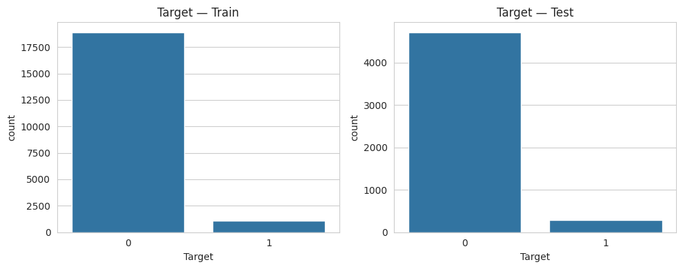

```
Train counts:
 Target
0    18890
1     1110
Name: count, dtype: int64
Train proportions:
 Target
0    0.9445
1    0.0555
Name: proportion, dtype: float64
```

```python
# Target distribution (class imbalance is critical for maintenance cost)
fig, ax = plt.subplots(1, 2, figsize=(10, 4))
sns.countplot(data=data, x='Target', ax=ax[0])
ax[0].set_title('Target — Train')
sns.countplot(data=test_data, x='Target', ax=ax[1])
ax[1].set_title('Target — Test')
plt.tight_layout()
plt.show()

print('Train counts:\n', data['Target'].value_counts())
print('Train proportions:\n', data['Target'].value_counts(normalize=True).round(4))
```

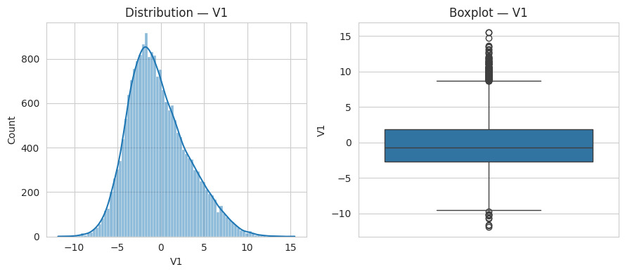

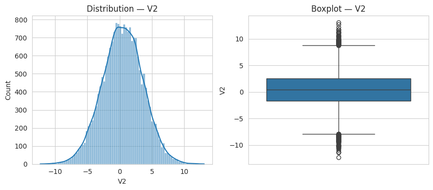

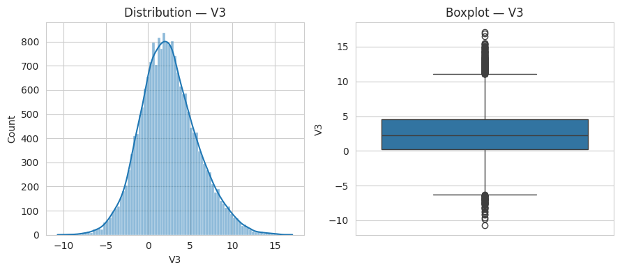

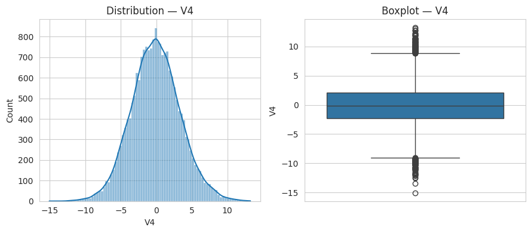

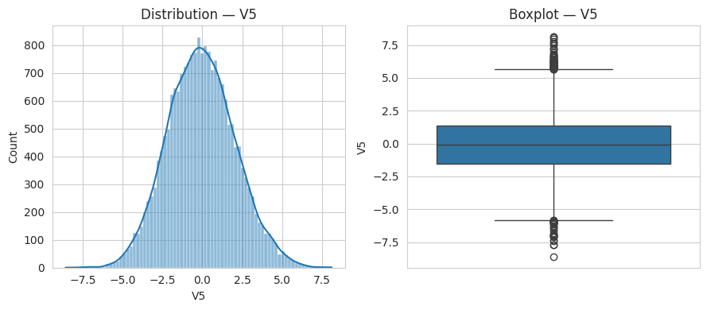

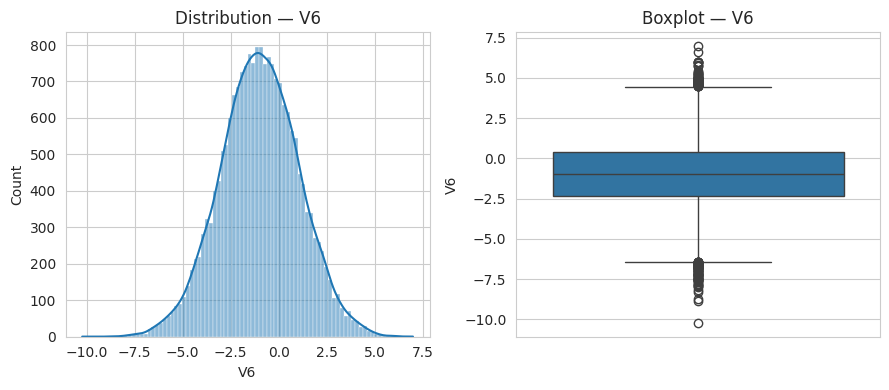

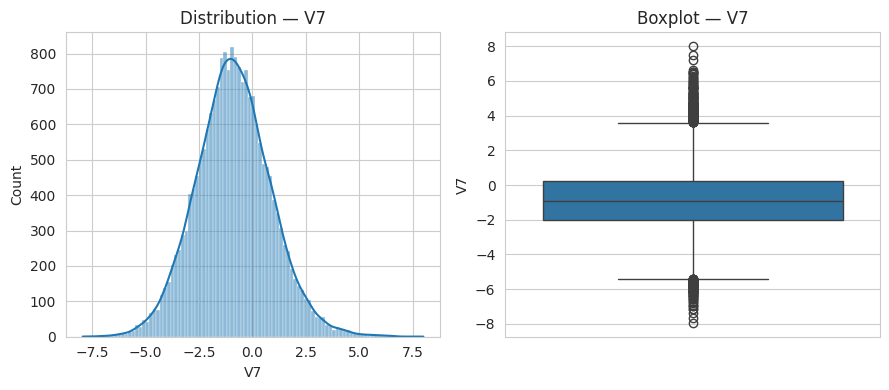

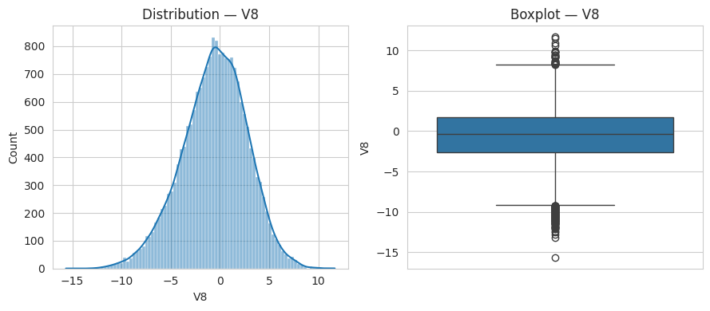

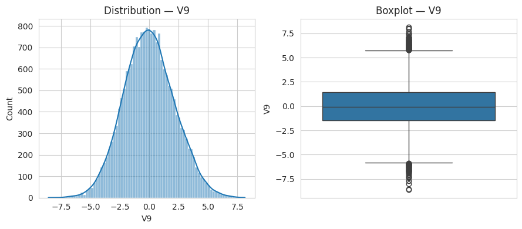

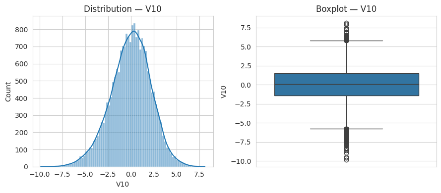

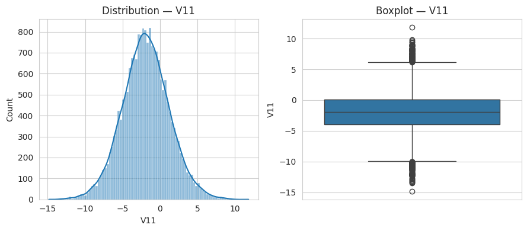

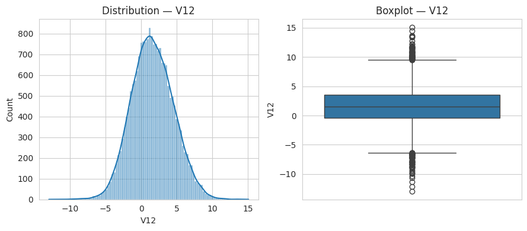

[28 more figures not shown]

```python
predictor_cols = [c for c in data.columns if c != 'Target']
# Univariate plots for all 40 sensor predictors
for feature in predictor_cols:
    histogram_boxplot(data, feature, figsize=(9, 4))
```

**Observation**

- Failures (Target = 1) are the minority class in train and test sets.
- Class proportions are similar across train and test.

## 4.3 - Bivariate Analysis

### 4.3.1 - Correlation Check

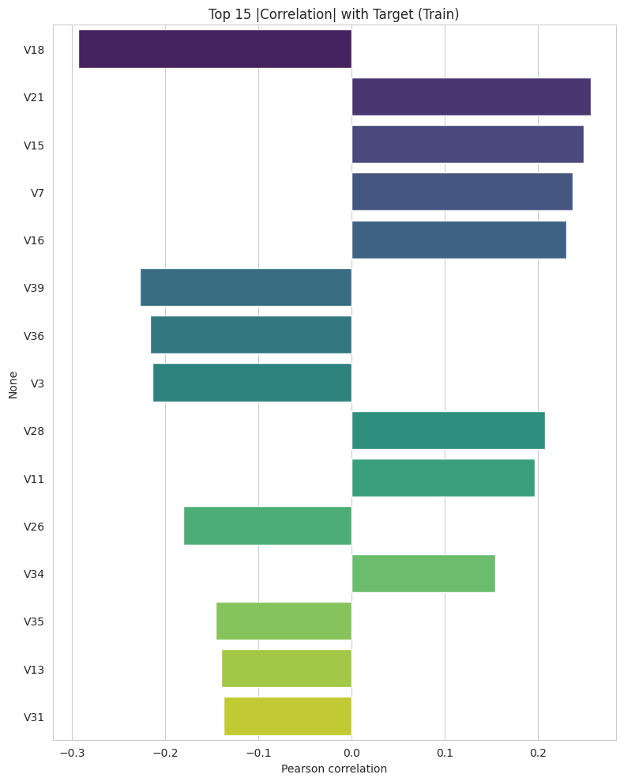

```python
predictor_cols = [c for c in data.columns if c != 'Target']
corr_with_target = data[predictor_cols + ['Target']].corr()['Target'].drop('Target').sort_values(key=abs, ascending=False)

plt.figure(figsize=(8, 10))
sns.barplot(x=corr_with_target.head(15).values, y=corr_with_target.head(15).index, palette='viridis')
plt.title('Top 15 |Correlation| with Target (Train)')
plt.xlabel('Pearson correlation')
plt.tight_layout()
plt.show()
```

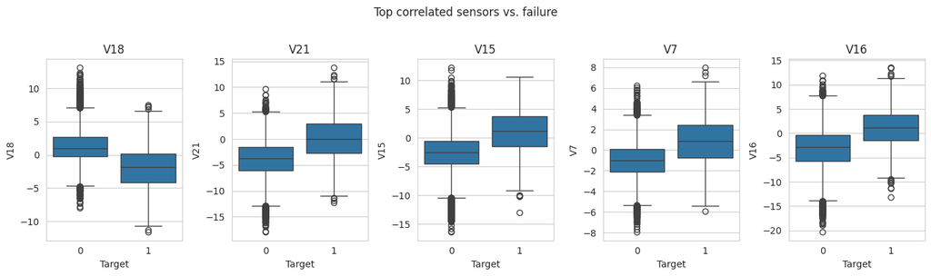

```python
top5 = corr_with_target.abs().sort_values(ascending=False).head(5).index.tolist()
fig, axes = plt.subplots(1, len(top5), figsize=(14, 4))
for ax, feat in zip(axes, top5):
    sns.boxplot(data=data, x='Target', y=feat, ax=ax)
    ax.set_title(feat)
plt.suptitle('Top correlated sensors vs. failure', y=1.02)
plt.tight_layout()
plt.show()
```

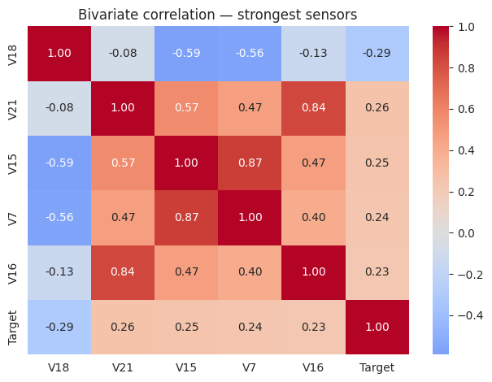

```python
# Pairwise correlation among top sensors + target
sns.heatmap(data[top5 + ['Target']].corr(), annot=True, fmt='.2f', cmap='coolwarm', center=0)
plt.title('Bivariate correlation — strongest sensors')
plt.tight_layout()
plt.show()
```

**Observation**

- Several predictors show correlation with the target variable.
- Distributions differ between failure and non-failure classes for top correlated sensors.

# 5 - Data Preprocessing

## 5.1 - Data Preparation for Modeling

```python
X = data.drop(columns=['Target'])
y = data['Target']

X_train, X_val, y_train, y_val = train_test_split(
    X, y, test_size=0.2, random_state=SEED, stratify=y
)

X_test = test_data.drop(columns=['Target'])
y_test = test_data['Target']

print('Train / val / test shapes:', X_train.shape, X_val.shape, X_test.shape)
print('Class balance (train):', y_train.value_counts(normalize=True).round(4).to_dict())
```

```
Train / val / test shapes: (16000, 40) (4000, 40) (5000, 40)
Class balance (train): {0: 0.9445, 1: 0.0555}
```

## 5.2 - Missing Value Imputation and Scaling

```python
imputer = SimpleImputer(strategy='median')
X_train = pd.DataFrame(imputer.fit_transform(X_train), columns=X.columns)
X_val = pd.DataFrame(imputer.transform(X_val), columns=X.columns)
X_test = pd.DataFrame(imputer.transform(X_test), columns=X.columns)

scaler = StandardScaler()
X_train = scaler.fit_transform(X_train)
X_val = scaler.transform(X_val)
X_test = scaler.transform(X_test)

y_train = y_train.to_numpy()
y_val = y_val.to_numpy()
y_test = y_test.to_numpy()

print('Missing after imputation (train):', np.isnan(X_train).sum())
```

```
Missing after imputation (train): 0
```

**Observation**

- Missing values in V1 and V2 are imputed using the training set median.
- Features are standardized using training data statistics.
- Imputation and scaling are performed after the train-validation split to avoid data leakage.
- The target variable is imbalanced; class weights will be used during model training.

# 6 - Model Building and Performance Improvement

## 6.1 - Model Evaluation Criterion

In this problem, we aim to predict generator failures, where:

- **Class 1** represents "Failure"
- **Class 0** represents "No failure"

When evaluating a classification model, we consider the following outcomes:

- **True Positives (TP)**: The model correctly predicts a "Failure" (Class 1) when the actual class is "Failure" (Class 1). These result in repair costs.
- **True Negatives (TN)**: The model correctly predicts "No failure" (Class 0) when the actual class is "No failure" (Class 0).
- **False Negatives (FN)**: The model incorrectly predicts "No failure" (Class 0) when the actual class is "Failure" (Class 1). These are costly as they lead to generator replacement.
- **False Positives (FP)**: The model incorrectly predicts "Failure" (Class 1) when the actual class is "No failure" (Class 0). These result in inspection costs.

Based on the problem description, the cost of a False Negative (replacement cost) is significantly higher than the cost of a False Positive (inspection cost), and the cost of a True Positive (repair cost) is less than the replacement cost.

For final model selection, we use a maintenance cost function on the validation set:

**Maintenance cost** = TP × $15,000 + FN × $40,000 + FP × $5,000

**Cost efficiency** = (TP + FN) × $15,000 ÷ Maintenance cost

The best model maximizes **cost efficiency** on the validation set (and minimizes maintenance cost as a tie-breaker). Recall is tracked during training and reported as a supporting metric.

## 6.2 - Define utility Functions

```python
REPAIR_COST = 15_000
REPLACEMENT_COST = 40_000
INSPECTION_COST = 5_000

def maintenance_cost(cm):
    tn, fp, fn, tp = cm.ravel()
    return tp * REPAIR_COST + fn * REPLACEMENT_COST + fp * INSPECTION_COST

def cost_efficiency(cm):
    tn, fp, fn, tp = cm.ravel()
    minimum = (tp + fn) * REPAIR_COST
    actual = maintenance_cost(cm)
    return minimum / actual if actual else 0.0

def model_performance(model, X, y, threshold=0.5, label=''):
    prob = model.predict(X, verbose=0).ravel()
    pred = (prob >= threshold).astype(int)
    cm = confusion_matrix(y, pred)
    df_perf = pd.DataFrame({
        'Accuracy': [accuracy_score(y, pred)],
        'Recall': [recall_score(y, pred, zero_division=0)],
        'Precision': [precision_score(y, pred, zero_division=0)],
        'F1': [f1_score(y, pred, zero_division=0)],
        'Maintenance_Cost': [maintenance_cost(cm)],
        'Cost_Efficiency': [cost_efficiency(cm)],
    }, index=[label or 'model'])
    return df_perf, cm

def plot_history(history, metric_name, title):
    # Keras may log metrics as 'Recall' / 'val_Recall'
    keys = list(history.history.keys())
    train_key = next((k for k in keys if metric_name.lower() in k.lower() and not k.startswith('val_')), keys[0])
    val_key = next((k for k in keys if metric_name.lower() in k.lower() and k.startswith('val_')), f'val_{train_key}')
    fig, ax = plt.subplots(figsize=(7, 4))
    ax.plot(history.history[train_key], label='Train')
    ax.plot(history.history[val_key], label='Validation')
    ax.set_xlabel('Epoch')
    ax.set_ylabel(metric_name.capitalize())
    ax.set_title(title)
    ax.legend()
    plt.tight_layout()
    plt.show()

def show_confusion(cm, title):
    plt.figure(figsize=(5, 4))
    sns.heatmap(cm, annot=True, fmt='d', cmap='Blues',
                xticklabels=['Pred 0', 'Pred 1'], yticklabels=['True 0', 'True 1'])
    plt.title(title)
    plt.ylabel('True label')
    plt.xlabel('Predicted label')
    plt.tight_layout()
    plt.show()

# Class weights for imbalance
counts = np.bincount(y_train.astype(int))
cw_dict = {i: len(y_train) / counts[i] for i in range(len(counts))}
cw_dict
```

```
{0: np.float64(1.0587612493382743), 1: np.float64(18.01801801801802)}
```

**Since the class is heavily imbalanced in the data, we'll use class weights in all the models except Model 5.**

```python
EPOCHS = 25
BATCH_SIZE = 32

results_train = {}
results_val = {}
results_test = {}
histories = {}

def train_and_evaluate(name, model, use_class_weight=True, config_note=''):
    tf.keras.backend.clear_session()
    start = time.time()
    fit_kwargs = dict(
        x=X_train, y=y_train,
        validation_data=(X_val, y_val),
        epochs=EPOCHS, batch_size=BATCH_SIZE,
        verbose=0,
    )
    if use_class_weight:
        fit_kwargs['class_weight'] = cw_dict
    history = model.fit(**fit_kwargs)
    elapsed = time.time() - start

    train_perf, _ = model_performance(model, X_train, y_train, label=name)
    val_perf, val_cm = model_performance(model, X_val, y_val, label=name)
    test_perf, test_cm = model_performance(model, X_test, y_test, label=name)

    results_train[name] = train_perf
    results_val[name] = val_perf
    results_test[name] = test_perf
    histories[name] = history

    plot_history(history, 'loss', f'{name} — Loss\n{config_note}')
    plot_history(history, 'recall', f'{name} — Recall\n{config_note}')
    show_confusion(val_cm, f'{name} — Validation confusion matrix')
    show_confusion(test_cm, f'{name} — Test confusion matrix (held-out)')

    val_cost = int(val_perf['Maintenance_Cost'].iloc[0])
    val_eff = val_perf['Cost_Efficiency'].iloc[0]
    print(f'Training time: {elapsed:.1f}s')
    print(f'Validation maintenance cost: ${val_cost:,} | Cost efficiency: {val_eff:.4f}')
    display(train_perf)
    display(val_perf)
    return model, val_perf
```

## 6.3 - Model 0 - Baseline Model

[output not shown]

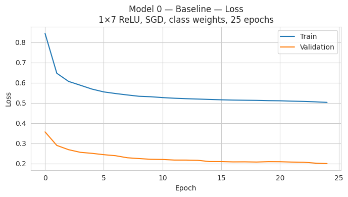

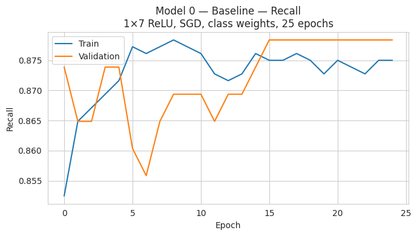

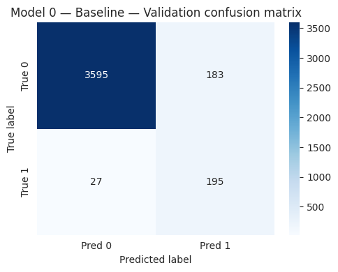

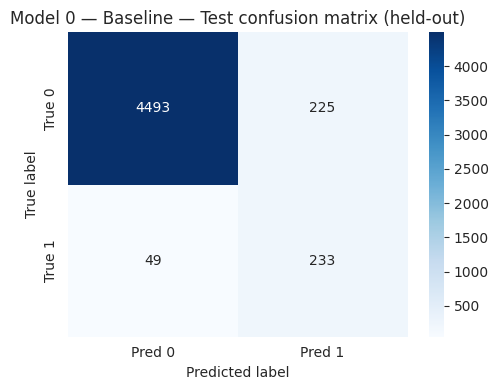

```
Training time: 18.3s
Validation maintenance cost: $4,920,000 | Cost efficiency: 0.6768
```

|  | Accuracy | Recall | Precision | F1 | Maintenance_Cost | Cost_Efficiency |
| --- | --- | --- | --- | --- | --- | --- |
| Model 0 — Baseline | 0.945063 | 0.876126 | 0.502909 | 0.639014 | 19915000 | 0.668843 |

|  | Accuracy | Recall | Precision | F1 | Maintenance_Cost | Cost_Efficiency |
| --- | --- | --- | --- | --- | --- | --- |
| Model 0 — Baseline | 0.9475 | 0.878378 | 0.515873 | 0.65 | 4920000 | 0.676829 |

```python
model_0 = Sequential([
    Input(shape=(X_train.shape[1],)),
    Dense(7, activation='relu'),
    Dense(1, activation='sigmoid'),
])
model_0.compile(loss='binary_crossentropy', optimizer=SGD(), metrics=['Recall'])
model_0, _ = train_and_evaluate(
    'Model 0 — Baseline',
    model_0,
    config_note='1×7 ReLU, SGD, class weights, 25 epochs',
)
```

**Observation**

- Model 0 establishes baseline performance with SGD and one hidden layer (7 neurons).
- Compare validation maintenance cost and cost efficiency with subsequent models.

## 6.4 - Model 1 - Add additional hidden layer

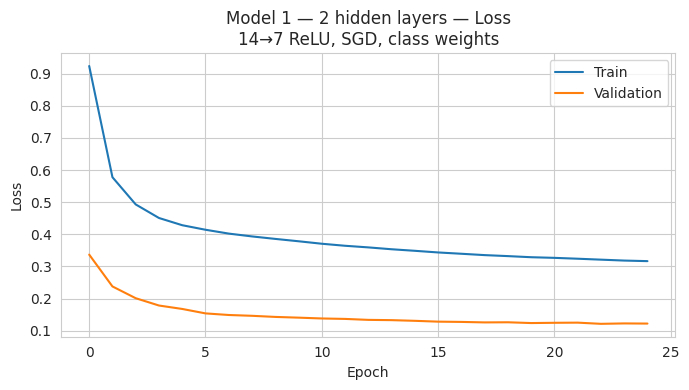

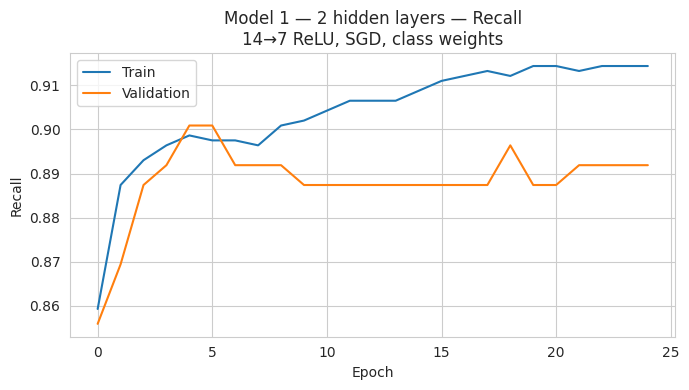

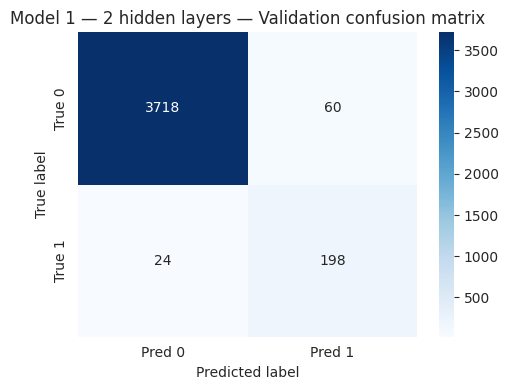

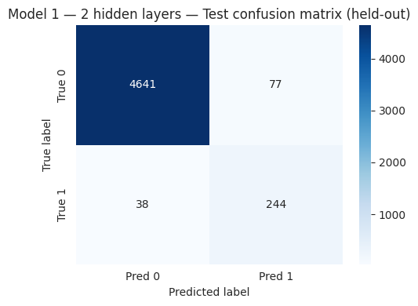

```
Training time: 18.9s
Validation maintenance cost: $4,230,000 | Cost efficiency: 0.7872
```

|  | Accuracy | Recall | Precision | F1 | Maintenance_Cost | Cost_Efficiency |
| --- | --- | --- | --- | --- | --- | --- |
| Model 1 — 2 hidden layers | 0.981875 | 0.916667 | 0.790291 | 0.848801 | 16250000 | 0.819692 |

|  | Accuracy | Recall | Precision | F1 | Maintenance_Cost | Cost_Efficiency |
| --- | --- | --- | --- | --- | --- | --- |
| Model 1 — 2 hidden layers | 0.979 | 0.891892 | 0.767442 | 0.825 | 4230000 | 0.787234 |

```python
model_1 = Sequential([
    Input(shape=(X_train.shape[1],)),
    Dense(14, activation='relu'),
    Dense(7, activation='relu'),
    Dense(1, activation='sigmoid'),
])
model_1.compile(loss='binary_crossentropy', optimizer=SGD(), metrics=['Recall'])
model_1, _ = train_and_evaluate(
    'Model 1 — 2 hidden layers',
    model_1,
    config_note='14→7 ReLU, SGD, class weights',
)
```

**Observation**

- Model 1 adds a second hidden layer (14 and 7 neurons).
- Review validation cost efficiency relative to Model 0.

## 6.5 - Model 2 - Add third hidden layer

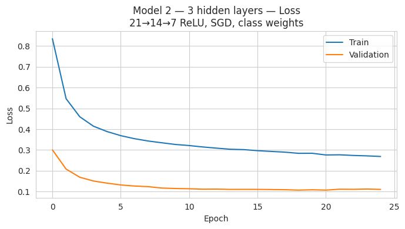

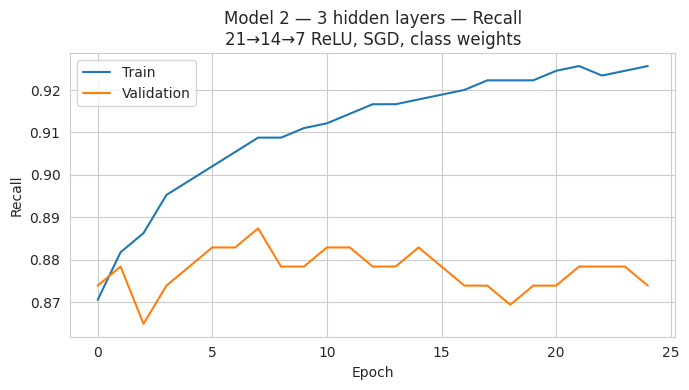

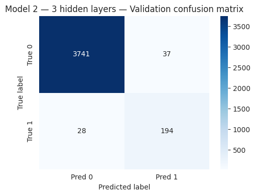

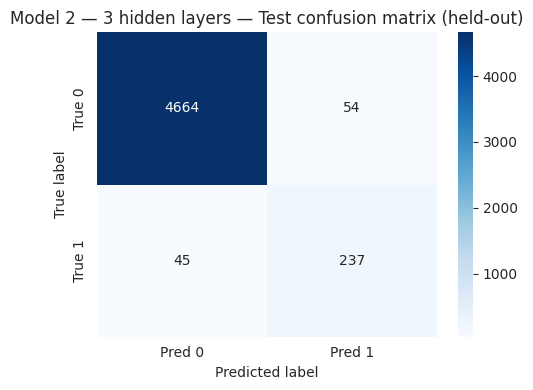

```
Training time: 19.5s
Validation maintenance cost: $4,215,000 | Cost efficiency: 0.7900
```

|  | Accuracy | Recall | Precision | F1 | Maintenance_Cost | Cost_Efficiency |
| --- | --- | --- | --- | --- | --- | --- |
| Model 2 — 3 hidden layers | 0.987688 | 0.92455 | 0.863302 | 0.892877 | 15645000 | 0.85139 |

|  | Accuracy | Recall | Precision | F1 | Maintenance_Cost | Cost_Efficiency |
| --- | --- | --- | --- | --- | --- | --- |
| Model 2 — 3 hidden layers | 0.98375 | 0.873874 | 0.839827 | 0.856512 | 4215000 | 0.790036 |

```python
model_2 = Sequential([
    Input(shape=(X_train.shape[1],)),
    Dense(21, activation='relu'),
    Dense(14, activation='relu'),
    Dense(7, activation='relu'),
    Dense(1, activation='sigmoid'),
])
model_2.compile(loss='binary_crossentropy', optimizer=SGD(), metrics=['Recall'])
model_2, _ = train_and_evaluate(
    'Model 2 — 3 hidden layers',
    model_2,
    config_note='21→14→7 ReLU, SGD, class weights',
)
```

**Observation**

- Model 2 uses three hidden layers (21, 14, and 7 neurons).
- Check whether validation maintenance cost improves versus Models 0 and 1.

## 6.6 - Model 3 - Change the optimizer to Adam

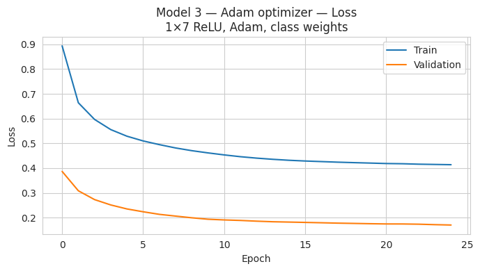

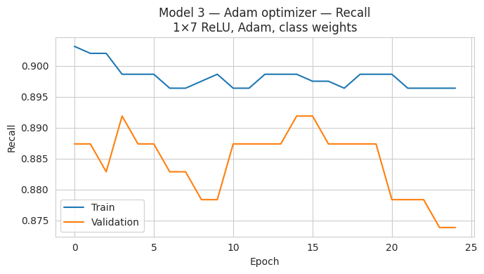

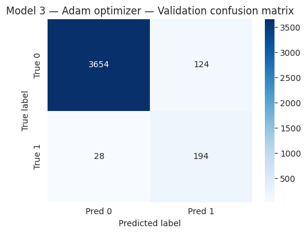

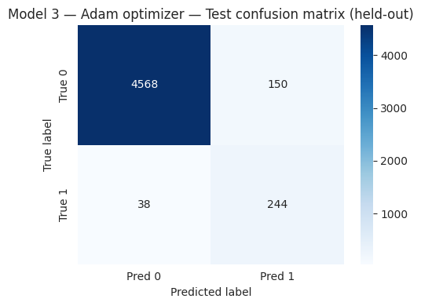

```
Training time: 19.5s
Validation maintenance cost: $4,650,000 | Cost efficiency: 0.7161
```

|  | Accuracy | Recall | Precision | F1 | Maintenance_Cost | Cost_Efficiency |
| --- | --- | --- | --- | --- | --- | --- |
| Model 3 — Adam optimizer | 0.9625 | 0.904279 | 0.609256 | 0.728015 | 18020000 | 0.739179 |

|  | Accuracy | Recall | Precision | F1 | Maintenance_Cost | Cost_Efficiency |
| --- | --- | --- | --- | --- | --- | --- |
| Model 3 — Adam optimizer | 0.962 | 0.873874 | 0.610063 | 0.718519 | 4650000 | 0.716129 |

```python
model_3 = Sequential([
    Input(shape=(X_train.shape[1],)),
    Dense(7, activation='relu'),
    Dense(1, activation='sigmoid'),
])
model_3.compile(loss='binary_crossentropy', optimizer=Adam(learning_rate=0.001), metrics=['Recall'])
model_3, _ = train_and_evaluate(
    'Model 3 — Adam optimizer',
    model_3,
    config_note='1×7 ReLU, Adam, class weights',
)
```

**Observation**

- Model 3 uses the Adam optimizer with the same architecture as Model 0.
- Compare validation maintenance cost and cost efficiency with SGD models.